# 10.22.20 Budweiser Analysis

Feby Thomas

10/22/2020

# Introduction

The analysis and code below is based off of the beer and brewery information provided by executive teams at Budweiser. The findings from the SMU Consulting Company, were prepared and are represented by data scientists: Zach Zaiken, Feby Thomas and Rinku Lichti. In the Code that follows, the team will be providing data inferences and key takeaways for each of the Budweiser Team’s questions and inquiries. The presentation is divided up into the sections below.

1. Data Import
2. Breweries by State
3. Impact of Missing Data
4. ABV & IBU by State
5. Distribution and Statistics of ABV
6. Relationship between ABV & IBU
7. IPA vs Ale
8. Opportunities for Market Expansion

# Data Import

The following code imports the beer and brewery data into R Studio, from here the data will be cleaned, transformed and modeled to answer various analysis questions and provide insight and key takeaways.

```r
library (readr)
beer_urlfile="https://raw.githubusercontent.com/BivinSadler/MSDS_6306_Doing-Data-Science/Master/Unit%208%20and%209%20Case%20Study%201/Beers.csv"
breweries_urlfile ="https://raw.githubusercontent.com/BivinSadler/MSDS_6306_Doing-Data-Science/Master/Unit%208%20and%209%20Case%20Study%201/Breweries.csv"

beer<-read_csv(url(beer_urlfile))
breweries<-read_csv(url(breweries_urlfile))
```

# Breweries By State

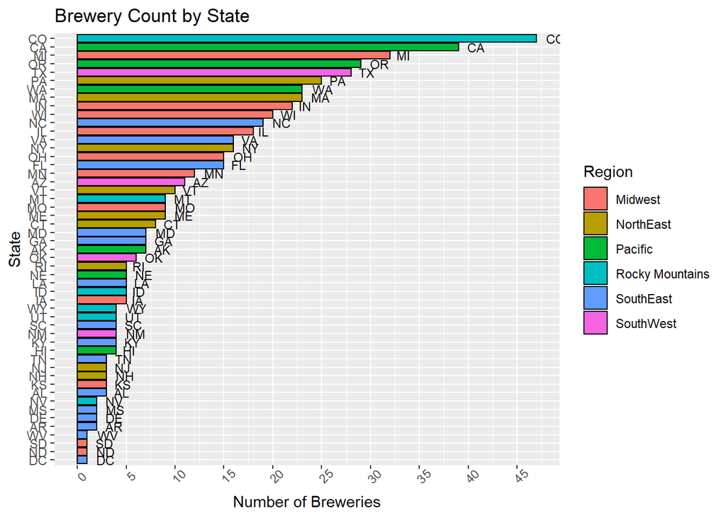

```r
library(tidyverse)

breweries_count <- breweries%>%group_by(State)%>%dplyr::summarize(count = n())%>%arrange(desc(count))

breweries_count$State = factor(breweries_count$State,level = breweries_count$State[order((breweries_count$count))])

breweries_count$Region = case_when(
  breweries_count$State == "CT" ~ "NorthEast",
  breweries_count$State == "ME" ~ "NorthEast",
  breweries_count$State == "MA" ~ "NorthEast",
  breweries_count$State == "NH" ~ "NorthEast",
  breweries_count$State == "RI" ~ "NorthEast",
  breweries_count$State == "VT" ~ "NorthEast",

  breweries_count$State == "NJ" ~ "NorthEast",
  breweries_count$State == "NY" ~ "NorthEast",
  breweries_count$State == "PA" ~ "NorthEast",

  breweries_count$State == "IL" ~ "Midwest",
  breweries_count$State == "IN" ~ "Midwest",
  breweries_count$State == "MI" ~ "Midwest",
  breweries_count$State == "OH" ~ "Midwest",
  breweries_count$State == "WI" ~ "Midwest",

  breweries_count$State == "IA" ~ "Midwest",
  breweries_count$State == "KS" ~ "Midwest",
  breweries_count$State == "MN" ~ "Midwest",
  breweries_count$State == "MN" ~ "Midwest",
  breweries_count$State == "MO" ~ "Midwest",
  breweries_count$State == "NB" ~ "Midwest",
  breweries_count$State == "ND" ~ "Midwest",
  breweries_count$State == "SD" ~ "Midwest",

  breweries_count$State == "DE" ~ "SouthEast",
  breweries_count$State == "FL" ~ "SouthEast",
  breweries_count$State == "GA" ~ "SouthEast",
  breweries_count$State == "MD" ~ "SouthEast",
  breweries_count$State == "NC" ~ "SouthEast",
  breweries_count$State == "SC" ~ "SouthEast",
  breweries_count$State == "VA" ~ "SouthEast",
  breweries_count$State == "WV" ~ "SouthEast",
  breweries_count$State == "DC" ~ "SouthEast",
  breweries_count$State == "AL" ~ "SouthEast",
  breweries_count$State == "KY" ~ "SouthEast",
  breweries_count$State == "MS" ~ "SouthEast",
  breweries_count$State == "TN" ~ "SouthEast",
  breweries_count$State == "AR" ~ "SouthEast",
  breweries_count$State == "LA" ~ "SouthEast",

  breweries_count$State == "OK" ~ "SouthWest",
  breweries_count$State == "TX" ~ "SouthWest",
  breweries_count$State == "AZ" ~ "SouthWest",
  breweries_count$State == "NM" ~ "SouthWest",

  breweries_count$State == "CO" ~ "Rocky Mountains",
  breweries_count$State == "ID" ~ "Rocky Mountains",
  breweries_count$State == "MT" ~ "Rocky Mountains",
  breweries_count$State == "NV" ~ "Rocky Mountains",
  breweries_count$State == "UT" ~ "Rocky Mountains",
  breweries_count$State == "WY" ~ "Rocky Mountains",

  TRUE ~ "Pacific")


breweries_count%>%ggplot(aes(x=State,y=count,fill=Region))+
geom_col(position = "dodge",col="black")+ylab("Number of Breweries")+
theme(axis.text.x = element_text(angle = 45))+
scale_y_continuous(breaks = scales::pretty_breaks(n = 10))+
  ggtitle("Brewery Count by State")+
  geom_text(aes(label=State),hjust = -0.5,size = 3)+ coord_flip()
```

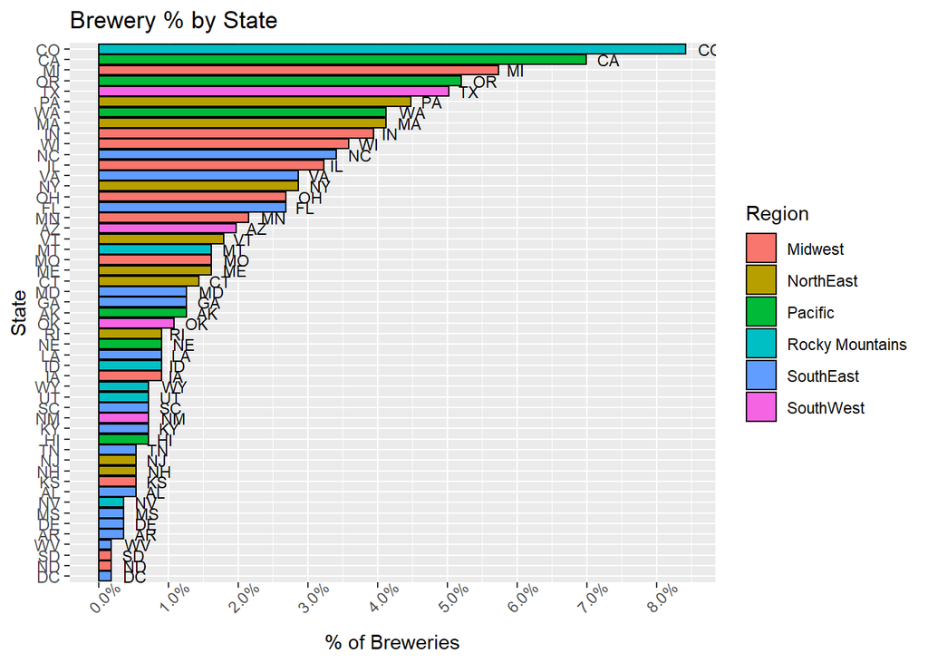

```r
breweries_count%>%ggplot(aes(x=State,y=count/length(breweries$Brew_ID),fill=Region))+
  geom_col(position = "dodge",col="black")+ylab("% of Breweries")+
  theme(axis.text.x = element_text(angle = 45))+
  scale_y_continuous(labels = scales::percent_format(accuracy = .5),breaks = scales::pretty_breaks(n = 10))+
  ggtitle("Brewery % by State")+
  geom_text(aes(label=State),hjust = -0.5,size = 3)+ coord_flip()
```

```r
library(gt)
breweries_count$Percent = breweries_count$count/length(breweries$Brew_ID)

BrewbyRegion <- breweries_count%>%group_by(Region)%>%dplyr::summarize(Total_Count = sum(count) ,Total_Percent=sum(Percent))%>%arrange(desc(Total_Percent))

BrewbyRegion%>%mutate(Cumulative_Percent = cumsum(BrewbyRegion$Total_Percent))%>%gt()%>%tab_header(title = "Breweries by Region")
```

Breweries by Region

| Region | Total_Count | Total_Percent | Cumulative_Percent |
| --- | --- | --- | --- |
| Midwest | 138 | 0.24731183 | 0.2473118 |
| Pacific | 107 | 0.19175627 | 0.4390681 |
| NorthEast | 102 | 0.18279570 | 0.6218638 |
| SouthEast | 91 | 0.16308244 | 0.7849462 |
| Rocky Mountains | 71 | 0.12724014 | 0.9121864 |
| SouthWest | 49 | 0.08781362 | 1.0000000 |

The following code produces a heat map showing the brewery count by state. Red indicates higher brewery count. Similar to above shows that CO,CA,MI,OR & TX have the most breweries by state.

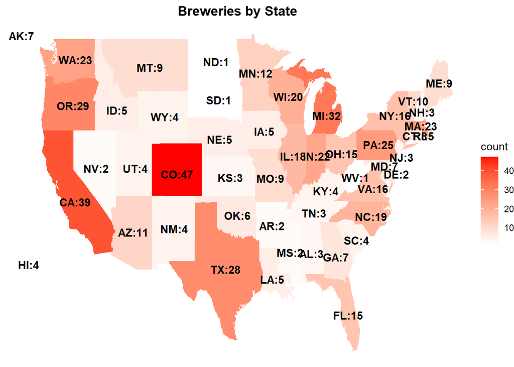

```r
library(ggplot2)
library(purrr)
library(dplyr)
library(tidyr)

states <- map_data("state")

findStateAbb <- function(state_name) {
  m <- match(tools::toTitleCase(state_name), state.name)
  if (is.na(m)) {
    return(NA)
  } else {
    return(state.abb[m])
  }
}
states$state <- map_chr(states$region, findStateAbb)

sbcm <- left_join(states, breweries_count, by=c("state" = "State"))



snames <- data.frame(state=state.abb, long=state.center$x, lat=state.center$y)
snames <- left_join(snames, breweries_count, by=c("state" = "State"))
snames <- snames%>%unite("comb", c("state", "count"), sep = ":", remove = FALSE)



ggplot(sbcm, aes(long, lat)) +
  geom_polygon(aes(group=group, fill=count )) + scale_fill_gradient(low="white", high="red") +
  geom_text(data=snames, aes(long, lat, label=comb), color="black", fontface = "bold") +
  theme_void() +
  ggtitle("Breweries by State") +
  theme(plot.title = element_text(hjust = 0.5, face="bold"))
```

# Merge Beer and Brewery Data

The code below standardizes the column names for breweries and beer so they have consistent names when the data is joined together. This is followed by performing a full join and an inner join of the beers and brewery data. The reason for this is to make sure these return the same output. There could be breweries in the beer table not in the brewery table and vice-versa. A summary of each of the merged data sets is done for quick visual inspection of each merge to check for any obvious differences. This is followed by utilizing the all.equal() function which checks for full equality between the data sets. Once full equality has been established, the inner join merge data will be used for all subsequent analysis questions. The code also shows the first 6 and last 6 rows of the merged data to show the join was done successfully.

```r
names(beer)[5] <- "Brew_ID"
names(beer)[1] <- "Beer_Name"
names(breweries)[2] <- "Brewery_Name"

beer_brewery_fulljoin <- full_join(beer,breweries, by = "Brew_ID")

beer_brewery_innerjoin <- inner_join(beer,breweries, by = "Brew_ID")


summary(beer_brewery_fulljoin)
```

```
##   Beer_Name            Beer_ID            ABV               IBU
##  Length:2410        Min.   :   1.0   Min.   :0.00100   Min.   :  4.00
##  Class :character   1st Qu.: 808.2   1st Qu.:0.05000   1st Qu.: 21.00
##  Mode  :character   Median :1453.5   Median :0.05600   Median : 35.00
##                     Mean   :1431.1   Mean   :0.05977   Mean   : 42.71
##                     3rd Qu.:2075.8   3rd Qu.:0.06700   3rd Qu.: 64.00
##                     Max.   :2692.0   Max.   :0.12800   Max.   :138.00
##                                      NA's   :62        NA's   :1005
##     Brew_ID         Style               Ounces      Brewery_Name
##  Min.   :  1.0   Length:2410        Min.   : 8.40   Length:2410
##  1st Qu.: 94.0   Class :character   1st Qu.:12.00   Class :character
##  Median :206.0   Mode  :character   Median :12.00   Mode  :character
##  Mean   :232.7                      Mean   :13.59
##  3rd Qu.:367.0                      3rd Qu.:16.00
##  Max.   :558.0                      Max.   :32.00
##
##      City              State
##  Length:2410        Length:2410
##  Class :character   Class :character
##  Mode  :character   Mode  :character
##
##
##
##
```

```r
summary(beer_brewery_innerjoin)
```

```
##   Beer_Name            Beer_ID            ABV               IBU
##  Length:2410        Min.   :   1.0   Min.   :0.00100   Min.   :  4.00
##  Class :character   1st Qu.: 808.2   1st Qu.:0.05000   1st Qu.: 21.00
##  Mode  :character   Median :1453.5   Median :0.05600   Median : 35.00
##                     Mean   :1431.1   Mean   :0.05977   Mean   : 42.71
##                     3rd Qu.:2075.8   3rd Qu.:0.06700   3rd Qu.: 64.00
##                     Max.   :2692.0   Max.   :0.12800   Max.   :138.00
##                                      NA's   :62        NA's   :1005
##     Brew_ID         Style               Ounces      Brewery_Name
##  Min.   :  1.0   Length:2410        Min.   : 8.40   Length:2410
##  1st Qu.: 94.0   Class :character   1st Qu.:12.00   Class :character
##  Median :206.0   Mode  :character   Median :12.00   Mode  :character
##  Mean   :232.7                      Mean   :13.59
##  3rd Qu.:367.0                      3rd Qu.:16.00
##  Max.   :558.0                      Max.   :32.00
##
##      City              State
##  Length:2410        Length:2410
##  Class :character   Class :character
##  Mode  :character   Mode  :character
##
##
##
##
```

```r
all.equal(beer_brewery_fulljoin,beer_brewery_innerjoin)
```

```
## [1] TRUE
```

```r
##first 6 rows
head(beer_brewery_innerjoin,6)
```

```
## # A tibble: 6 x 10
##   Beer_Name  Beer_ID   ABV   IBU Brew_ID Style   Ounces Brewery_Name City  State
##   <chr>        <dbl> <dbl> <dbl>   <dbl> <chr>    <dbl> <chr>        <chr> <chr>
## 1 Pub Beer      1436 0.05     NA     409 Americ~     12 10 Barrel B~ Bend  OR
## 2 Devil's C~    2265 0.066    NA     178 Americ~     12 18th Street~ Gary  IN
## 3 Rise of t~    2264 0.071    NA     178 Americ~     12 18th Street~ Gary  IN
## 4 Sinister      2263 0.09     NA     178 Americ~     12 18th Street~ Gary  IN
## 5 Sex and C~    2262 0.075    NA     178 Americ~     12 18th Street~ Gary  IN
## 6 Black Exo~    2261 0.077    NA     178 Oatmea~     12 18th Street~ Gary  IN
```

```r
#last 6 rows
tail(beer_brewery_innerjoin,6)
```

```
## # A tibble: 6 x 10
##   Beer_Name   Beer_ID   ABV   IBU Brew_ID Style  Ounces Brewery_Name City  State
##   <chr>         <dbl> <dbl> <dbl>   <dbl> <chr>   <dbl> <chr>        <chr> <chr>
## 1 Rocky Moun~    1035 0.075    NA     425 Ameri~     12 Wynkoop Bre~ Denv~ CO
## 2 Belgorado       928 0.067    45     425 Belgi~     12 Wynkoop Bre~ Denv~ CO
## 3 Rail Yard ~     807 0.052    NA     425 Ameri~     12 Wynkoop Bre~ Denv~ CO
## 4 B3K Black ~     620 0.055    NA     425 Schwa~     12 Wynkoop Bre~ Denv~ CO
## 5 Silverback~     145 0.055    40     425 Ameri~     12 Wynkoop Bre~ Denv~ CO
## 6 Rail Yard ~      84 0.052    NA     425 Ameri~     12 Wynkoop Bre~ Denv~ CO
```

# Missing Values

1.all samples

2.beers with only missing IBU

3.beers with no missing IBU.

The shape of ABV remains the same across all 3, which implies the “ABV vs Correlation” analysis can continue without the missing IBU values.

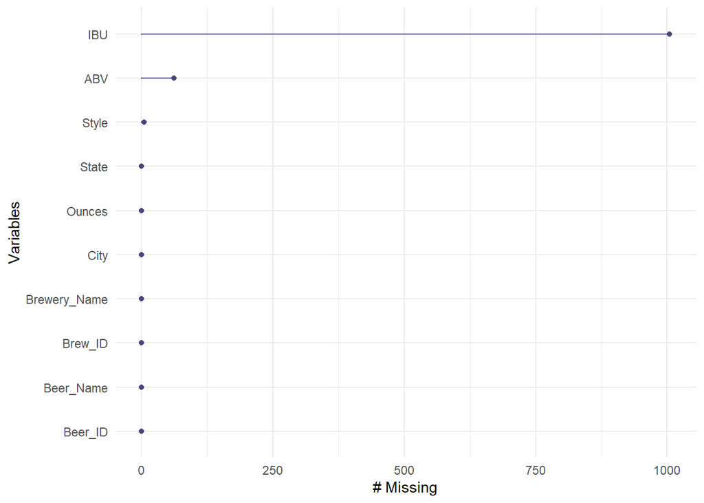

```r
library(GGally)
library(naniar)


gg_miss_var(beer_brewery_innerjoin)
```

```r
miss_var_summary(beer_brewery_innerjoin)%>%gt()%>%tab_header(title = "Missing Data Summary")
```

Missing Data Summary

| variable | n_miss | pct_miss |
| --- | --- | --- |
| IBU | 1005 | 41.7012448 |
| ABV | 62 | 2.5726141 |
| Style | 5 | 0.2074689 |
| Beer_Name | 0 | 0.0000000 |
| Beer_ID | 0 | 0.0000000 |
| Brew_ID | 0 | 0.0000000 |
| Ounces | 0 | 0.0000000 |
| Brewery_Name | 0 | 0.0000000 |
| City | 0 | 0.0000000 |
| State | 0 | 0.0000000 |

```r
sapply(beer_brewery_innerjoin,function(x) sum(is.na(x)))
```

```
##    Beer_Name      Beer_ID          ABV          IBU      Brew_ID        Style
##            0            0           62         1005            0            5
##       Ounces Brewery_Name         City        State
##            0            0            0            0
```

```r
beer_brewery_innerjoin_IPAtest <- beer_brewery_innerjoin%>%
  mutate(IPA_test =
           grepl("IPA",beer_brewery_innerjoin$Style),
         Ale_test = grepl("Ale",beer_brewery_innerjoin$Style),
         India_test = grepl("India",beer_brewery_innerjoin$Style),
         Pale_test = grepl("Pale",beer_brewery_innerjoin$Style),)



##classify all beer as IPA, ALE or other
Beer_brewery_Classify <- beer_brewery_innerjoin_IPAtest%>%mutate(Beer_Classify = case_when(
  IPA_test == "TRUE" ~ "IPA",
  Ale_test == "TRUE" ~ "Ale",
  TRUE ~ "Other"))

#seperate out null IBU beer
beer_brewery_nullIBU <- Beer_brewery_Classify %>% filter(is.na(IBU))


Beer_brewery_Classify_Total <- Beer_brewery_Classify%>%group_by(Beer_Classify)%>%dplyr::summarize(TotalCount = n())%>%arrange(desc(TotalCount))


beer_brewery_nullIBU_Total <- beer_brewery_nullIBU%>%group_by(Beer_Classify)%>%dplyr::summarize(MissingCount = n())%>%arrange(desc(MissingCount))


#Impact of missing Values on Ale vs IPA analysis
 left_join(Beer_brewery_Classify_Total,beer_brewery_nullIBU_Total, by = "Beer_Classify")%>%mutate(Percent_Missing = MissingCount/TotalCount)%>%
   gt()%>%tab_header(title = "Analysis of Missing Values on Ale vs IPA")
```

Analysis of Missing Values on Ale vs IPA

| Beer_Classify | TotalCount | MissingCount | Percent_Missing |
| --- | --- | --- | --- |
| Ale | 963 | 411 | 0.4267913 |
| Other | 876 | 415 | 0.4737443 |
| IPA | 571 | 179 | 0.3134851 |

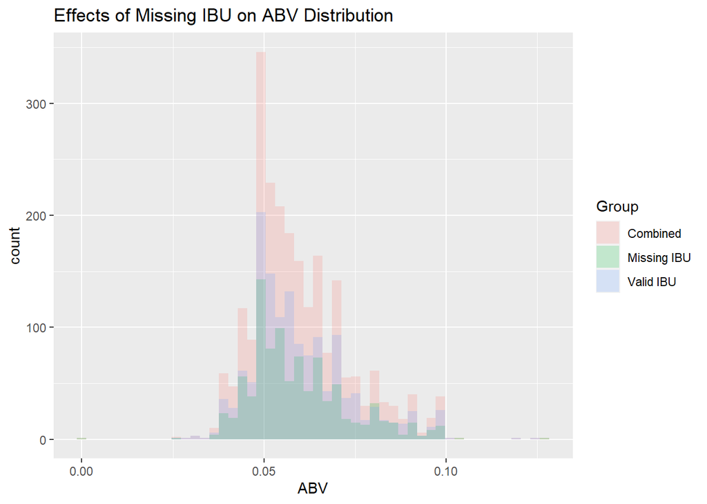

```r
 ABV_NULLIBU <- data.frame(Beer_brewery_Classify%>%filter(is.na(IBU)&!is.na(ABV))%>%select(ABV))
 ABV_NOTNULLIBU <- data.frame(Beer_brewery_Classify%>%filter(!is.na(IBU)&!is.na(ABV))%>%select(ABV))
 ABV_ALLIBU <- data.frame(Beer_brewery_Classify%>%filter(!is.na(ABV))%>%select(ABV))

 ABV_NULLIBU$Group = "Missing IBU"
 ABV_NOTNULLIBU$Group = "Valid IBU"
 ABV_ALLIBU$Group = "Combined"

 ggplot(union_all(union_all(ABV_NULLIBU,ABV_NOTNULLIBU),ABV_ALLIBU), aes(x = ABV, fill = Group)) +                       # Draw overlaying histogram
   geom_histogram(position = "identity", alpha = 0.2, bins = 50)+ggtitle("Effects of Missing IBU on ABV Distribution")
```

# Median alcohol content and international bitterness unit for each state

The following code removes the missing ABV values from the merged data set, finds the median ABV value for each state, then charts the results in a bar chart by median value descending. Higher Median ABV seen in South East States (KY, DC ,WV). Higher Brewery regions (Pacific & Midwest Region) have lower median ABV.

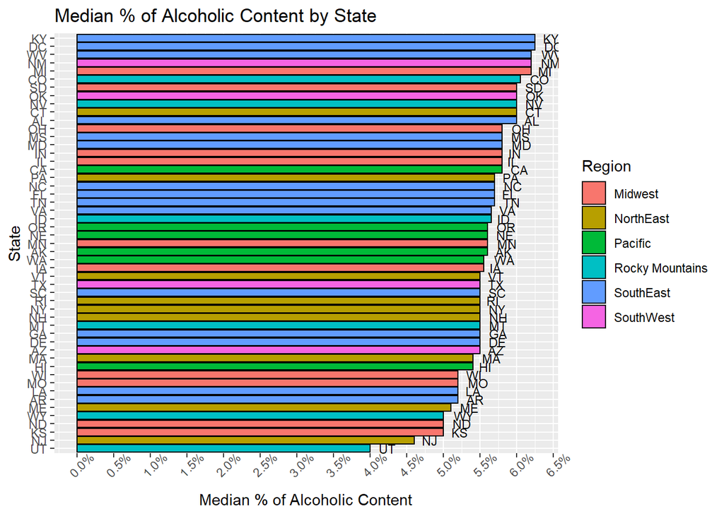

```r
alc_content <- beer_brewery_innerjoin%>%filter(!is.na(ABV))
alc_content_median <- alc_content%>%group_by(State)%>%dplyr::summarize(Median_Alcoholic_Content = median(ABV))%>%arrange(desc(Median_Alcoholic_Content))
alc_content_median$State = factor(alc_content_median$State,level = alc_content_median$State[order((alc_content_median$Median_Alcoholic_Content))])

alc_content_median <- left_join(alc_content_median,breweries_count%>%distinct(State,Region),by = "State")



alc_content_median%>%ggplot(aes(x=State,y=Median_Alcoholic_Content,fill=Region))+
  geom_col(position = "dodge",col="black")+ylab("Median % of Alcoholic Content")+
  theme(axis.text.x = element_text(angle = 45))+
  scale_y_continuous(labels = scales::percent_format(accuracy = .5),breaks = scales::pretty_breaks(n = 10))+
  ggtitle("Median % of Alcoholic Content by State")+ coord_flip()+
  geom_text(aes(label=State),hjust = -0.5,size = 3)
```

The following code removes the missing IBU values from the merged data set, finds the median IBU value for each state, then charts the results in a bar chart by median value descending. Higher Median IBU seen in South East States (WV, GA ,FL) with the largest being a North East outlier Maine (ME). Higher Brewery regions (Pacific & Midwest Region) have lower median IBU.

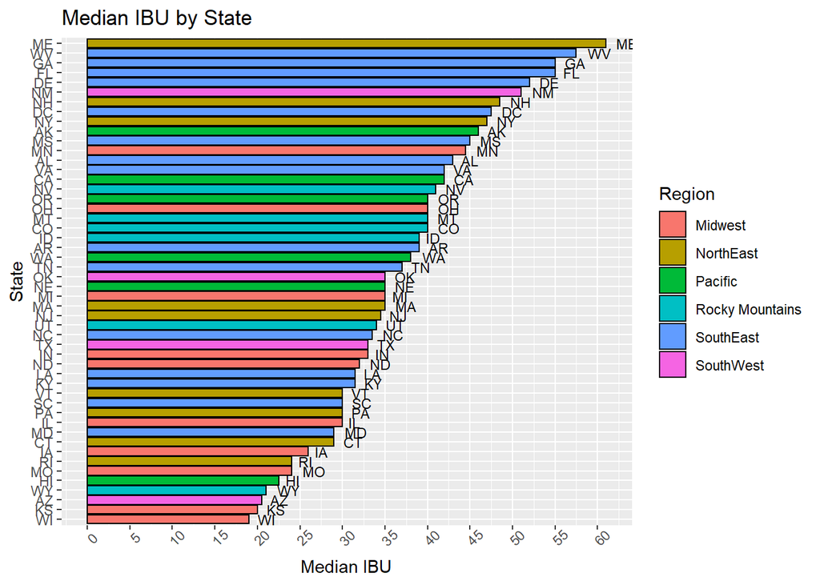

```r
IBU_content <- beer_brewery_innerjoin%>%filter(!is.na(IBU))
IBU_content_median <- IBU_content%>%group_by(State)%>%dplyr::summarize(Median_IBU = median(IBU))%>%arrange(desc(Median_IBU))
IBU_content_median$State = factor(IBU_content_median$State,level = IBU_content_median$State[order((IBU_content_median$Median_IBU))])


IBU_content_median <- left_join(IBU_content_median,breweries_count%>%distinct(State,Region),by = "State")


IBU_content_median%>%ggplot(aes(x=State,y=Median_IBU,fill=Region))+
  geom_col(position = "dodge",col="black")+ylab("Median IBU")+
  theme(axis.text.x = element_text(angle = 45))+
  scale_y_continuous(breaks = scales::pretty_breaks(n = 10))+
  ggtitle("Median IBU by State")+ coord_flip()+
  geom_text(aes(label=State),hjust = -0.5,size = 3)
```

# Max alcohol content and international bitterness unit for each state

1. CO: Lee Hill Series Vol. 5 - Belgian Style Quadrupel Ale (12.8% ABV)
2. KY: London Balling (12.5% ABV)
3. IN: Csar Russian Imperial Stout (12.0% ABV)

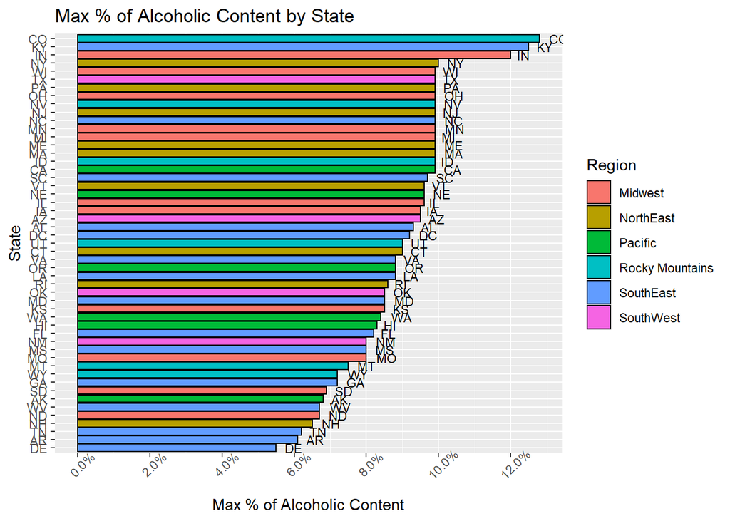

```r
alc_content_max <- alc_content%>%group_by(State)%>%dplyr::summarize(Max_Alcoholic_Content = max(ABV))%>%arrange(desc(Max_Alcoholic_Content))
alc_content_max$State = factor(alc_content_max$State,level = alc_content_max$State[order((alc_content_max$Max_Alcoholic_Content))])


alc_content_max <- left_join(alc_content_max,breweries_count%>%distinct(State,Region),by = "State")


alc_content_max%>%ggplot(aes(x=State,y=Max_Alcoholic_Content,fill=Region))+
  geom_col(position = "dodge",col="black")+ylab("Max % of Alcoholic Content")+
  theme(axis.text.x = element_text(angle = 45))+
  scale_y_continuous(labels = scales::percent_format(accuracy = .5),breaks = scales::pretty_breaks(n = 10))+
  ggtitle("Max % of Alcoholic Content by State")+ coord_flip()+
  geom_text(aes(label=State),hjust = -0.5,size = 3)
```

```r
head(alc_content%>%group_by(Beer_Name,State)%>%dplyr::summarize(Max_Alcoholic_Content = max(ABV))%>%arrange(desc(Max_Alcoholic_Content)))
```

```
## # A tibble: 6 x 3
## # Groups:   Beer_Name [6]
##   Beer_Name                                           State Max_Alcoholic_Conte~
##   <chr>                                               <chr>                <dbl>
## 1 Lee Hill Series Vol. 5 - Belgian Style Quadrupel A~ CO                   0.128
## 2 London Balling                                      KY                   0.125
## 3 Csar                                                IN                   0.12
## 4 Lee Hill Series Vol. 4 - Manhattan Style Rye Ale    CO                   0.104
## 5 4Beans                                              NY                   0.1
## 6 3Beans                                              NY                   0.099
```

The following code removes the missing IBU values from the merged data set, finds the max IBU value for each state, then charts the results in a bar chart by max value descending. In addition provides examples of the beers that have the highest IBU values. The states with the highest IBU values are OR & VA. The beers that make up these max values are:

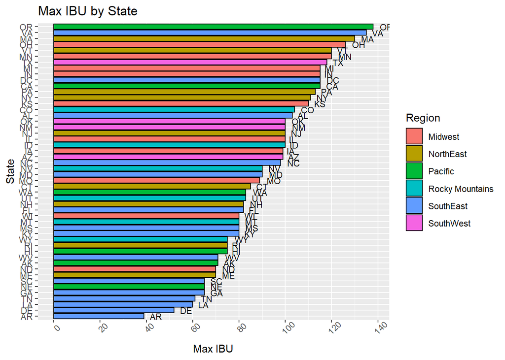

```r
IBU_content_max <- IBU_content%>%group_by(State)%>%dplyr::summarize(Max_IBU = max(IBU))%>%arrange(desc(Max_IBU))
IBU_content_max$State = factor(IBU_content_max$State,level = IBU_content_max$State[order((IBU_content_max$Max_IBU))])
IBU_content_max <- left_join(IBU_content_max,breweries_count%>%distinct(State,Region),by = "State")


IBU_content_max%>%ggplot(aes(x=State,y=Max_IBU,fill=Region))+
  geom_col(position = "dodge",col="black")+ylab("Max IBU")+
  theme(axis.text.x = element_text(angle = 45))+
  scale_y_continuous(breaks = scales::pretty_breaks(n = 10))+
  ggtitle("Max IBU by State")+coord_flip()+
  geom_text(aes(label=State),hjust = -0.5,size = 3)
```

```r
head(IBU_content%>%group_by(Beer_Name,State)%>%dplyr::summarize(Max_IBU = max(IBU))%>%arrange(desc(Max_IBU)))
```

```
## # A tibble: 6 x 3
## # Groups:   Beer_Name [6]
##   Beer_Name                       State Max_IBU
##   <chr>                           <chr>   <dbl>
## 1 Bitter Bitch Imperial IPA       OR        138
## 2 Troopers Alley IPA              VA        135
## 3 Dead-Eye DIPA                   MA        130
## 4 Bay of Bengal Double IPA (2014) OH        126
## 5 Abrasive Ale                    MN        120
## 6 Heady Topper                    VT        120
```

# Summary statistics and distribution of the ABV variable

```r
alc_content%>%
summarize(Mean = mean(ABV),Standard_Deviation = sd(ABV),Median = median(ABV), Lower_Quartile = quantile(ABV, prob=.2500),Upper_Quartile = quantile(ABV, prob=.7500))%>%
gt()%>%tab_header(title = "Summary Statistics of ABV")
```

Summary Statistics of ABV

| Mean | Standard_Deviation | Median | Lower_Quartile | Upper_Quartile |
| --- | --- | --- | --- | --- |
| 0.05977342 | 0.01354173 | 0.056 | 0.05 | 0.067 |

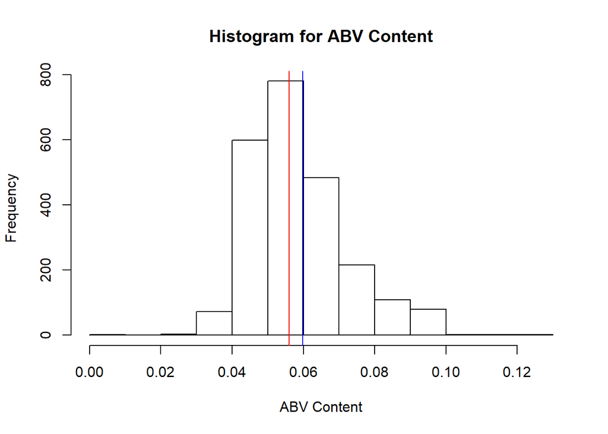

```r
hist(alc_content$ABV,main="Histogram for ABV Content", xlab="ABV Content")
abline(v=mean(alc_content$ABV),col="blue") #mean
abline(v=median(alc_content$ABV),col="red") #median
```

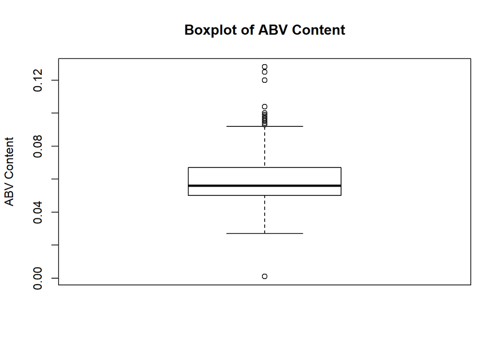

```r
boxplot(alc_content$ABV,ylab = "ABV Content",main = "Boxplot of ABV Content")
```

```r
#library("car")
#qqPlot(alc_content$ABV,ylab="ABV Content")+title("QQ-plot of ABV Content")
```

# Relationship between the bitterness of the beer and its alcoholic content

The code below first removes the beers with missing IBU and ABV values. The data is then run through the ggpairs() function which shows the shape and distribution of each variable, creates a scatter plot to identify visual evidence of linear correlation , and also provides the pearsons correlation coefficient. A separate scatter plot with a smooth line is also created to show evidence of the visual correlation. The graph shows strong visual evidence of correlation. This is supported by Pearson’s correlation coefficient for linear fit of .671. The Correlation can be explained easily from a brewing perspective, more hops are used to create more bitter beers, to offset or balance the taste brewers add more sugar. Sugar will ferment to create a higher alcoholic content.

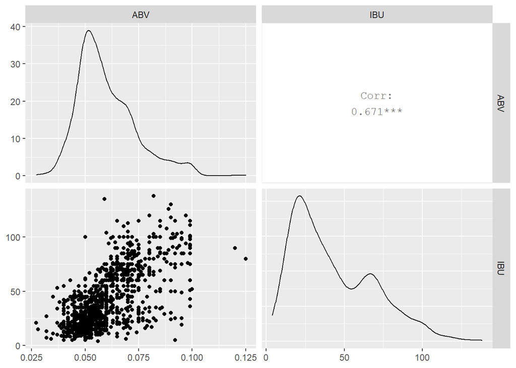

```r
Beer_Clean = beer_brewery_innerjoin %>% filter(!is.na(ABV) & !is.na(IBU))


Beer_Clean%>%select(ABV,IBU)%>%ggpairs()
```

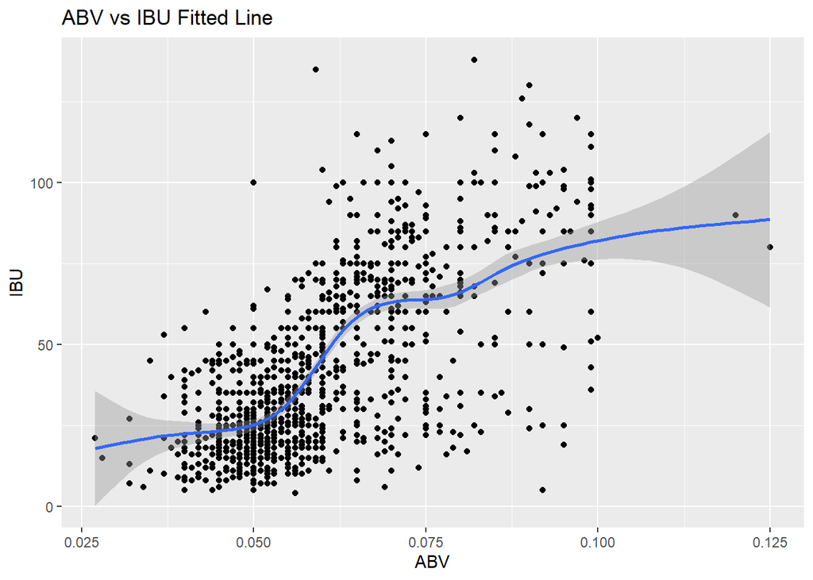

```r
Beer_Clean%>%select(ABV,IBU)%>%ggplot(aes(x=ABV,y=IBU))+geom_point()+geom_smooth()+ggtitle("ABV vs IBU Fitted Line")
```

# Relationship between IPA and Ale

The code below will examine the relationship between IPA and Ale through multiple steps:

1. Scatter plot of ABV vs IBU with for IPA and Ale
2. KNN Test/Train Cross Validation
3. KNN Leave-One-Out Cross Validation
4. Naive-Bayes conditional probability model

### 1. Scatter plot of ABV vs IBU with for IPA and Ale

The code below creates a scatter plot of ABV vs IBU looking only as beers identified as IPA or Pale Ale. Based on a beer’s style code is ran to classify it as either IPA, Ale or other (which is excluded form this analysis). The scatter plot is then color coded to show which beers are Ale and IPA. The graph will show strong evidence of clustering based on the ABV & IBU of the beer that will be explored through the KNN and Naive Bayes procedures.

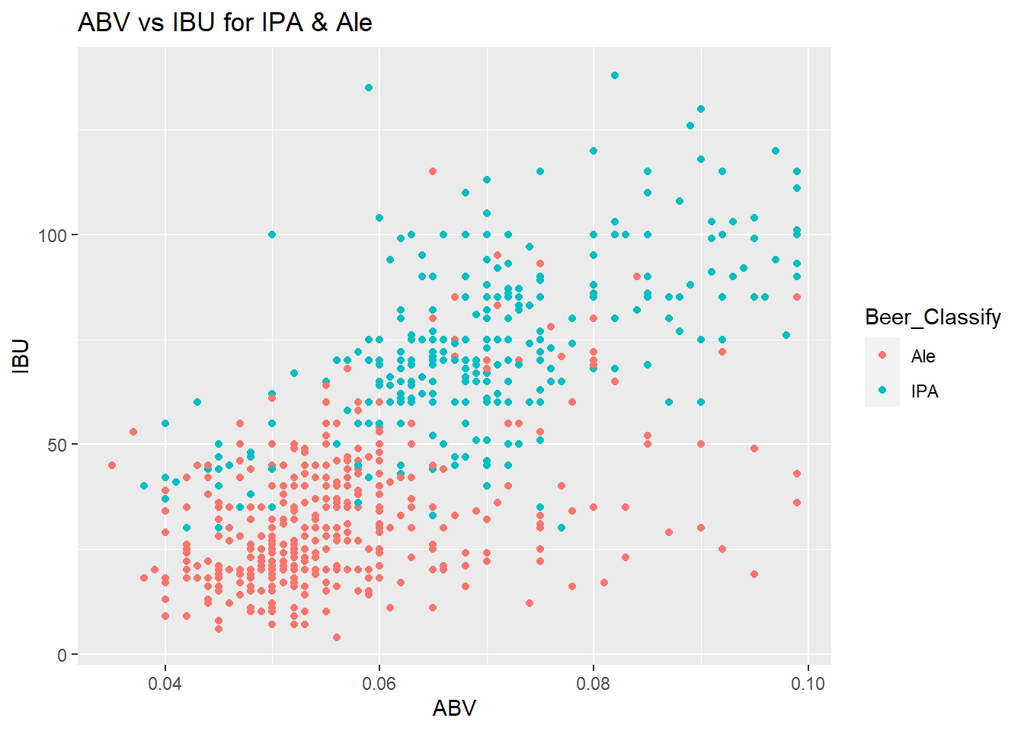

```r
Beer_Type <- Beer_Clean%>%group_by(Style)%>%dplyr::summarise(count =n())%>%arrange(desc(count))#%>%print(n=91)


Beer_Type_Analysis <- Beer_Type%>%
  mutate(
    IPA_test = grepl("IPA",Beer_Type$Style),
    Ale_test = grepl("Ale",Beer_Type$Style),
    India_test = grepl("India",Beer_Type$Style),
    Pale_test = grepl("Pale",Beer_Type$Style))


Beer_Type_Classify <- Beer_Type_Analysis%>%mutate(Beer_Classify = case_when(
  IPA_test == "TRUE" ~ "IPA",
  Ale_test == "TRUE" ~ "Ale",
  TRUE ~ "Other"))


left_join(Beer_Clean,Beer_Type_Classify%>%select(Style,Beer_Classify),by = "Style")%>%
  filter(Beer_Classify == "Ale" | Beer_Classify == "IPA")%>%select(ABV,IBU,Beer_Classify)%>%
  ggplot(aes(x=ABV,y=IBU,fill=Beer_Classify,color=Beer_Classify))+geom_point()+ggtitle("ABV vs IBU for IPA & Ale")
```

### 2. KNN Test/Train Cross Validation

The scatter plot of ABV vs IBU for IPA and Ale shows strong evidence of clustering. Ale is more predominant in the lower left quadrant having lower ABV and IBU values, and IPA in the top right quadrant with higher ABV and IBU. The following code will run a KNN Test/Train Model (abbreviated as KNN-TT) to test the statistical evidence of this correlation. The concept of KNN is any point on the scatter plot will be categorized as either Ale or IPA depending on the classification of the majority of the nearest neighboring points. The number of nearest neighboring points used is the “K-variable”, K can be set to any value.

The KNN-TT will randomly break the data set into two groups, a testing and training set. The test set is usually smaller, in this case will be 30% of the samples, and the remaining 70% going to the training set. Each value of the test set will be matched up against the training set for when identifying nearest neighboring points. The concept here that by testing a random part of your sample against itself, this checks the accuracy of the prospective model prior to adding or testing new values.

The KNN-TT will return 3 primary statistics:

1. Accuracy: the number of all correct predictions divided by the total number of the dataset
2. Sensitivity: the number of correct positive predictions divided by the total number of positives
3. Specificity: the number of correct negative predictions divided by the total number of negatives

To maximize the accuracy of the KNN-TT model, 500 simulations of different random Test/Train sets will be conducted. In addition the number of nearest neighbors (k-value) will be tested 1-50 for each of the 500 simulations.

```r
library(class)
library(caret)
Beer_Clean_Classify <- left_join(Beer_Clean,Beer_Type_Classify, by = "Style")
Beer_Ale_Or_IPA <- Beer_Clean_Classify%>%filter(Beer_Classify == "IPA"|Beer_Classify == "Ale")


iterations = 500
numks = 50
split_perc = .7

beer_k_tt_masterAcc = matrix(nrow=iterations, ncol = numks)
beer_k_tt_masterSpef = matrix(nrow=iterations, ncol = numks)
beer_k_tt_masterSens = matrix(nrow=iterations, ncol = numks)

for(j in 1:iterations)
{
  accs = data.frame(accuracy = numeric(50),k=numeric(50))
  train_Indicies = sample(1:dim(Beer_Ale_Or_IPA)[1],round(split_perc*dim(Beer_Ale_Or_IPA)[1]))
  train = Beer_Ale_Or_IPA[train_Indicies,]
  test = Beer_Ale_Or_IPA[-train_Indicies,]
  train <- train%>%mutate(ABV_scaled = scale(ABV), IBU_scaled = scale(IBU))
  test <- test%>%mutate(ABV_scaled = scale(ABV), IBU_scaled = scale(IBU))

  for(i in 1:50)
  {
    classifications = knn(train%>%select(ABV_scaled,IBU_scaled),test%>%select(ABV_scaled,IBU_scaled),train$Beer_Classify,prob=TRUE,k=i)
    table(test$Beer_Classify,classifications)
    CM_beer_k_tt = confusionMatrix(table(test$Beer_Classify,classifications))
    beer_k_tt_masterAcc[j,i] = CM_beer_k_tt$overall[1]
    beer_k_tt_masterSpef[j,i] = CM_beer_k_tt$byClass[2]
    beer_k_tt_masterSens[j,i] = CM_beer_k_tt$byClass[1]
  }
}

beer_k_tt_meanAcc = colMeans(beer_k_tt_masterAcc)
beer_k_tt_meanSens = colMeans(beer_k_tt_masterSens)
beer_k_tt_meanSpef = colMeans(beer_k_tt_masterSpef)


#results of accuracy for K
head(data.frame(
  K_value = seq(1,numks,1)
  ,Avg_Accuracy = beer_k_tt_meanAcc
  ,Avg_Sensitivity = beer_k_tt_meanSens
  ,Avg_Specificity = beer_k_tt_meanSpef)%>%arrange(desc(Avg_Accuracy)))%>%gt()%>%tab_header(title = "KNN-70/30 Test/Train Model (500 iterations of K:1-50)")
```

KNN-70/30 Test/Train Model (500 iterations of K:1-50)

| K_value | Avg_Accuracy | Avg_Sensitivity | Avg_Specificity |
| --- | --- | --- | --- |
| 36 | 0.8555336 | 0.8837054 | 0.8189707 |
| 39 | 0.8554558 | 0.8836804 | 0.8186911 |
| 37 | 0.8554417 | 0.8834560 | 0.8189921 |
| 35 | 0.8552792 | 0.8831911 | 0.8189982 |
| 38 | 0.8552650 | 0.8834522 | 0.8185877 |
| 41 | 0.8552226 | 0.8837335 | 0.8181123 |

### 3. KNN Leave-One-Out Cross Validation

The scatter plot of ABV vs IBU for IPA and Ale shows strong evidence of clustering. Ale is more predominant in the lower left quadrant having lower ABV and IBU values, and IPA in the top right quadrant with higher ABV and IBU. The following code will run a KNN Leave-One-Out Model (abbreviated as KNN-LO) to test the statistical evidence of this correlation. The concept of KNN is any point on the scatter plot will be categorized as either Ale or IPA depending on the classification of the majority of the nearest neighboring points. The number of nearest neighboring points used is the “K-variable”, K can be set to any value.

The KNN-LO will test each element of the sample against all other elements for determining the nearest neighboring points. The concept here that by testing a each sample against all others, this checks the accuracy of the prospective model prior to adding or testing new values.

The KNN-LO will return 3 primary statistics:

1. Accuracy: the number of all correct predictions divided by the total number of the dataset
2. Sensitivity: the number of correct positive predictions divided by the total number of positives
3. Specificity: the number of correct negative predictions divided by the total number of negatives

To maximize the accuracy of the KNN-LO model, 500 simulations will be conducted. In addition the number of nearest neighbors (k-value) will be tested 1-50 for each of the 500 simulations.

The code returns, based on the 500 simulations what values of K produce the most accurate clustering results. The KNN-LO model reveals accuracy, sensitivity and specificity levels around 86%,88% and 84% respectively. The K-value maximizes these figures when between 20s-30s. The KNN-LO model corroborates the KNN-TT model and proves there is strong evidence of statistical clustering between IPA and other Ales.

```r
library(class)
library(caret)

Beer_Ale_Or_IPA$ABV_scaled = scale(Beer_Ale_Or_IPA$ABV)
Beer_Ale_Or_IPA$IBU_scaled = scale(Beer_Ale_Or_IPA$IBU)

iterations = 500
numks = 50

masterAcc_l = matrix(nrow=iterations, ncol = numks)
masterSens_l = matrix(nrow=iterations, ncol = numks)
masterSpef_l = matrix(nrow=iterations, ncol = numks)


for(j in 1:iterations)
{
  accs_l = data.frame(accuracy = numeric(50),k=numeric(50))

  for(i in 1:50)
  { classifications_l = knn.cv(Beer_Ale_Or_IPA%>%select(ABV_scaled,IBU_scaled),Beer_Ale_Or_IPA$Beer_Classify,prob=TRUE,k=i)

  CM_l = confusionMatrix(table(Beer_Ale_Or_IPA$Beer_Classify,classifications_l))
  masterAcc_l[j,i] = CM_l$overall[1]
  masterSpef_l[j,i] = CM_l$byClass[2]
  masterSens_l[j,i] = CM_l$byClass[1]


  }
}

meanAcc_l = colMeans(masterAcc_l)
meanSens_l = colMeans(masterSens_l)
meanSpef_l = colMeans(masterSpef_l)

k_results_l <- data.frame(kvalue = seq(1,numks,1),
accuracy_avg = meanAcc_l,
Sensitivity_avg = meanSens_l,
Specificity_avg = meanSpef_l
)


head(k_results_l%>%arrange(desc(accuracy_avg)))%>%gt()%>%tab_header(title = "KNN-Leave one Out (500 iterations of K:1-50)")
```

KNN-Leave one Out (500 iterations of K:1-50)

| kvalue | accuracy_avg | Sensitivity_avg | Specificity_avg |
| --- | --- | --- | --- |
| 23 | 0.8680742 | 0.8861708 | 0.8424318 |
| 29 | 0.8670742 | 0.8804823 | 0.8474832 |
| 27 | 0.8653157 | 0.8807359 | 0.8430355 |
| 48 | 0.8650212 | 0.8899121 | 0.8311086 |
| 30 | 0.8649873 | 0.8779958 | 0.8458914 |
| 37 | 0.8649407 | 0.8956203 | 0.8245516 |

### 4. Naive-Bayes Model

The scatter plot of ABV vs IBU for IPA and Ale shows strong evidence of clustering. Ale is more predominant in the lower left quadrant having lower ABV and IBU values, and IPA in the top right quadrant with higher ABV and IBU. The following code will run a Naive-Bayes Model (abbreviated as NB) to test the statistical evidence of this correlation. The concept of NB is any point on the scatter plot will be categorized as either Ale or IPA depending based on conditional probabilities. It works on Bayes theorem of probability to predict the class of data sets.

The NB will return 3 primary statistics:

1. Accuracy: the number of all correct predictions divided by the total number of the dataset
2. Sensitivity: the number of correct positive predictions divided by the total number of positives
3. Specificity: the number of correct negative predictions divided by the total number of negatives

To maximize the accuracy of the NB model, 500 simulations will be conducted. The NB model reveals accuracy, sensitivity and specificity levels around 84%,86% and 80% respectively. The NB model corroborates the KNN model and proves there is strong evidence of statistical clustering between IPA and other Ales.

```r
library(e1071)
iterations_nb = 500
masterAcc_nb = matrix(nrow = iterations)
masterSens_nb = matrix(nrow = iterations)
masterSpef_nb = matrix(nrow = iterations)
splitPerc = .7 #Training / Test split Percentage
for(j in 1:iterations_nb)
{

  trainIndices_nb = sample(1:dim(Beer_Ale_Or_IPA)[1],round(splitPerc * dim(Beer_Ale_Or_IPA)[1]))
  train_nb = Beer_Ale_Or_IPA[trainIndices_nb,]
  test_nb = Beer_Ale_Or_IPA[-trainIndices_nb,]

  model_nb = naiveBayes(train_nb%>%select(ABV,IBU),as.factor(train_nb$Beer_Classify),laplace = 1)
  table(predict(model_nb,test_nb%>%select(ABV,IBU)),as.factor(test_nb$Beer_Classify))
  CM_nb = confusionMatrix(table(predict(model_nb,test_nb%>%select(ABV,IBU)),as.factor(test_nb$Beer_Classify)))
  masterAcc_nb[j] = CM_nb$overall[1]
  masterSens_nb[j] = CM_nb$byClass[1]
  masterSpef_nb[j] = CM_nb$byClass[2]
}
MeanAcc_nb = colMeans(masterAcc_nb)
MeanSens_nb = colMeans(masterSens_nb)
MeanSpef_nb = colMeans(masterSpef_nb)

nb_results <- data.frame(
                          accuracy_avg = MeanAcc_nb,
                          Sensitivity_avg = MeanSens_nb,
                          Specificity_avg = MeanSpef_nb)%>%gt()%>%tab_header(title = "Naive-Bayes (500 iterations)")

nb_results
```

Naive-Bayes (500 iterations)

| accuracy_avg | Sensitivity_avg | Specificity_avg |
| --- | --- | --- |
| 0.8425654 | 0.867707 | 0.8076397 |

# Market Expansion Opportunities

The beer and brewery data provides the current landscape as to what markets are served and what products are being sold nationwide. The following code will provide summaries on the following:

1. Breweries Per Million People of State Population
2. The most popular beer style by state and nationally
3. The least popular beer style by state and nationally

### 1. Breweries Per Million People of State Population

The code below creates a bar chart showing the brewery density by each state’s population. The States are sorted in descending order based on State Population, similary the states are color coded to show which states have the highest populations. The bars in the chart show the brewery density while the labels show the population of each state. The reccommendation would be for Budweiser to amp up opening up breweries in the Group 1 & Group 2 State Population Ranking groups. States like CA, TX, FL have potential for many more breweries to be oponed based on state population and are nowhere near as dense as states like CO, OR or VT.

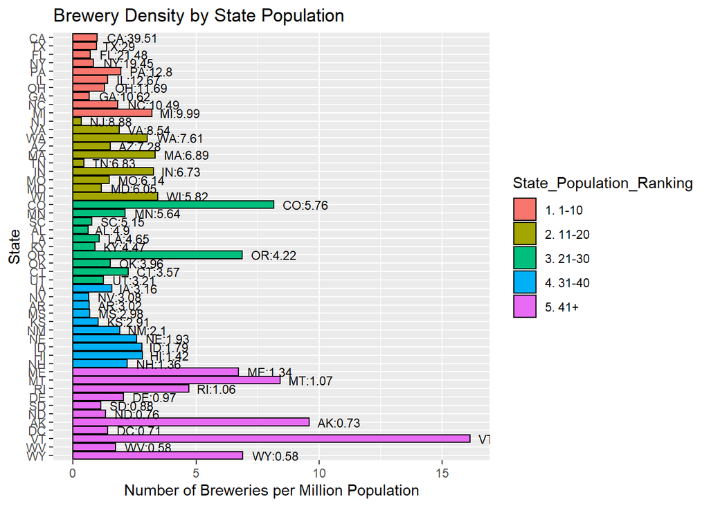

```r
breweries_count$Population = c(5.76,39.51,9.99,4.22,29,12.8,6.89,7.61,6.73,5.82,10.49,12.67,19.45,8.54,21.48,11.69,

                               5.64,7.28,0.62,1.34,6.14,1.07,3.57,0.73,10.62,6.05,3.96,3.16,1.79,4.65,1.93,1.06,

                               1.42,4.47,2.1,5.15,3.21,0.58,4.9,2.91,1.36,8.88,6.83,3.02,0.97,2.98,3.08,0.71,0.76,0.88,0.58)

breweries_count <-breweries_count%>%arrange(desc(Population))

breweries_count$rank = order(order(breweries_count$Population, decreasing=TRUE))


breweries_count$State_Population_Ranking = case_when(
  breweries_count$rank <= 10 ~ "1. 1-10",
  breweries_count$rank <= 20 ~ "2. 11-20",
  breweries_count$rank <= 30 ~ "3. 21-30",
  breweries_count$rank <= 40 ~ "4. 31-40",
  TRUE ~ "5. 41+")

breweries_count$State = factor(breweries_count$State,level = breweries_count$State[order(((breweries_count$Population)))])

breweries_count <- breweries_count%>%unite("comb", c("State", "Population"), sep = ":", remove = FALSE)

breweries_count%>%ggplot(aes(y=State,x=count/ Population,fill=State_Population_Ranking))+

  geom_col(position = "dodge",col="black")+xlab("Number of Breweries per Million Population")+

  theme(axis.text.y = element_text(angle = 0))+

  ggtitle("Brewery Density by State Population")+

  geom_text(aes(label=comb),hjust = -0.2,size = 3)
```

### 2. The most popular beer style by state and nationally

The code below shows what the most popular beer style served is by state, by taking a count of the unique beer names and summarizing by style and state. The graph reveals that American IPA & Pale Ales are the most popular in the biggest brewery markets (CO,CA,MI,OR) as well as nationwide. The recommendation would be for Budweiser to amp up production and development of IPA and Pale Ale products and lead with these products in any kind of new brewery or market expansion. Special attention should be given to states like CT, OK, GA where IPA/Pale ale is not the most popular, product offerings can be curtailed to their individual tastes.

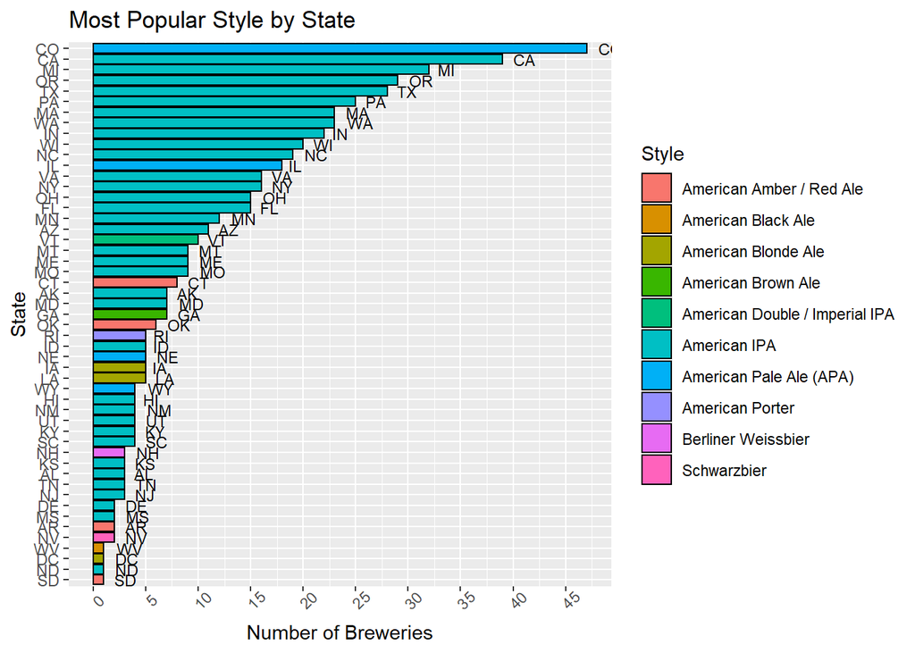

```r
library(data.table)
beer_style1_byState <- beer_brewery_innerjoin%>%distinct(Beer_Name,Style,State)%>%group_by(State,Style)%>%summarize(count=n())
beer_style1_byState <- as.data.table(beer_style1_byState)

beer_style1_byState[,valRank:=rank(-count,ties.method="first"),by="State"]

beer_style1_byState1 <- left_join(breweries_count,as.data.frame(beer_style1_byState)%>%filter(valRank==1)%>%select(State,Style), by= c("State" = "State"))

beer_style1_byState1$State = factor(beer_style1_byState1$State,level = beer_style1_byState1$State[order((beer_style1_byState1$count))])

beer_style1_byState1%>%
ggplot(aes(x=State,y=count,fill=Style))+
  geom_col(position = "dodge",col="black")+ylab("Number of Breweries")+
  theme(axis.text.x = element_text(angle = 45))+
  scale_y_continuous(breaks = scales::pretty_breaks(n = 10))+
  ggtitle("Most Popular Style by State")+
  geom_text(aes(label=State),hjust = -0.5,size = 3)+ coord_flip()
```

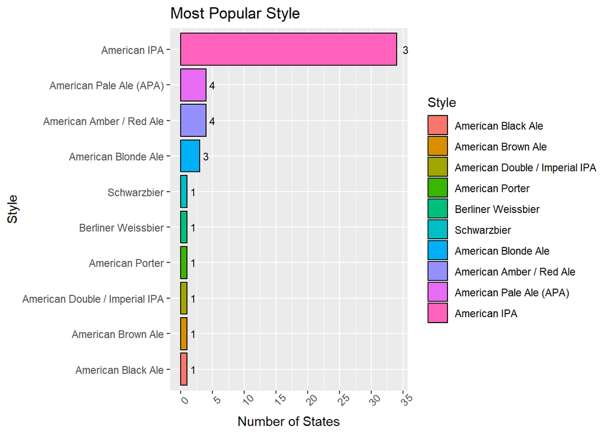

```r
beer_style1_byState1_agr <- beer_style1_byState1%>%group_by(Style)%>%summarize(State_Total=n())
beer_style1_byState1_agr$Style = factor(beer_style1_byState1_agr$Style,level = beer_style1_byState1_agr$Style[order((beer_style1_byState1_agr$State_Total))])


beer_style1_byState1_agr%>%
  ggplot(aes(x=Style,y=State_Total,fill=Style))+
  geom_col(position = "dodge",col="black")+ylab("Number of States")+
  theme(axis.text.x = element_text(angle = 45))+
  scale_y_continuous(breaks = scales::pretty_breaks(n = 10))+
  ggtitle("Most Popular Style")+
  geom_text(aes(label=State_Total),hjust = -0.5,size = 3)+coord_flip()
```

### 3. The least popular beer style by state and nationally

The code below shows what the least popular beer style served is by state, by taking a count of the unique beer names and summarizing by style and state. The graph reveals that American Amber/Red Ale & Altbier are the least popular in the biggest brewery markets (CO,MI,OR,TX) as well as nationwide. The recommendation would be for Budweiser to phase out or limit products American Amber/Red Ale & Altbier and not lead with these products in any kind of new brewery or market expansion. Special attention should be given to CA, with competition in CA from established wineries, perhaps American Barleywine should be phased out

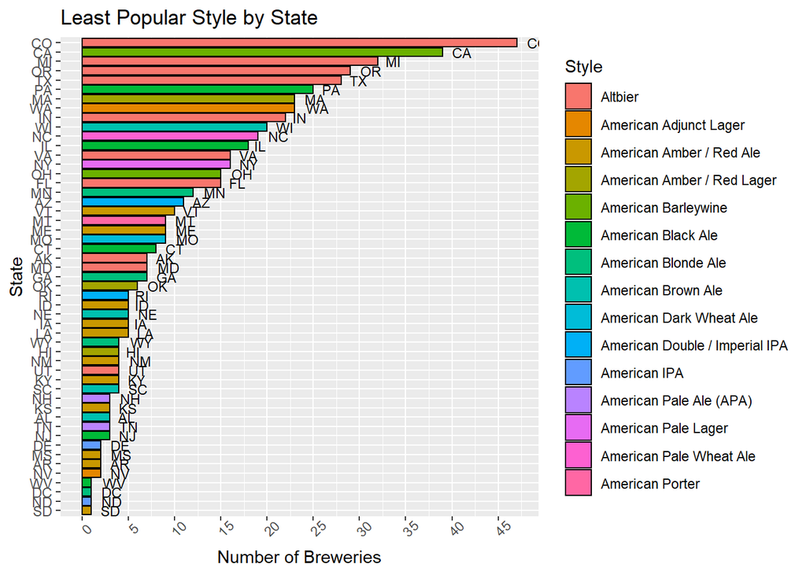

```r
library(data.table)
beer_style1_byState <- beer_brewery_innerjoin%>%distinct(Beer_Name,Style,State)%>%group_by(State,Style)%>%summarize(count=n())
beer_style1_byState <- as.data.table(beer_style1_byState)

beer_style1_byState[,LastRank:=rank(count,ties.method="first"),by="State"]

beer_style_last_byState1 <- left_join(breweries_count,as.data.frame(beer_style1_byState)%>%filter(LastRank==1)%>%select(State,Style), by= c("State" = "State"))

beer_style_last_byState1$State = factor(beer_style_last_byState1$State,level = beer_style_last_byState1$State[order((beer_style_last_byState1$count))])

beer_style_last_byState1_agr <- beer_style_last_byState1%>%group_by(Style)%>%summarize(State_Total=n())
beer_style_last_byState1_agr$Style = factor(beer_style_last_byState1_agr$Style,level = beer_style_last_byState1_agr$Style[order((beer_style_last_byState1_agr$State_Total))])


beer_style_last_byState1%>%
  ggplot(aes(x=State,y=count,fill=Style))+
  geom_col(position = "dodge",col="black")+ylab("Number of Breweries")+
  theme(axis.text.x = element_text(angle = 45))+
  scale_y_continuous(breaks = scales::pretty_breaks(n = 10))+
  ggtitle("Least Popular Style by State")+
  geom_text(aes(label=State),hjust = -0.5,size = 3)+ coord_flip()
```

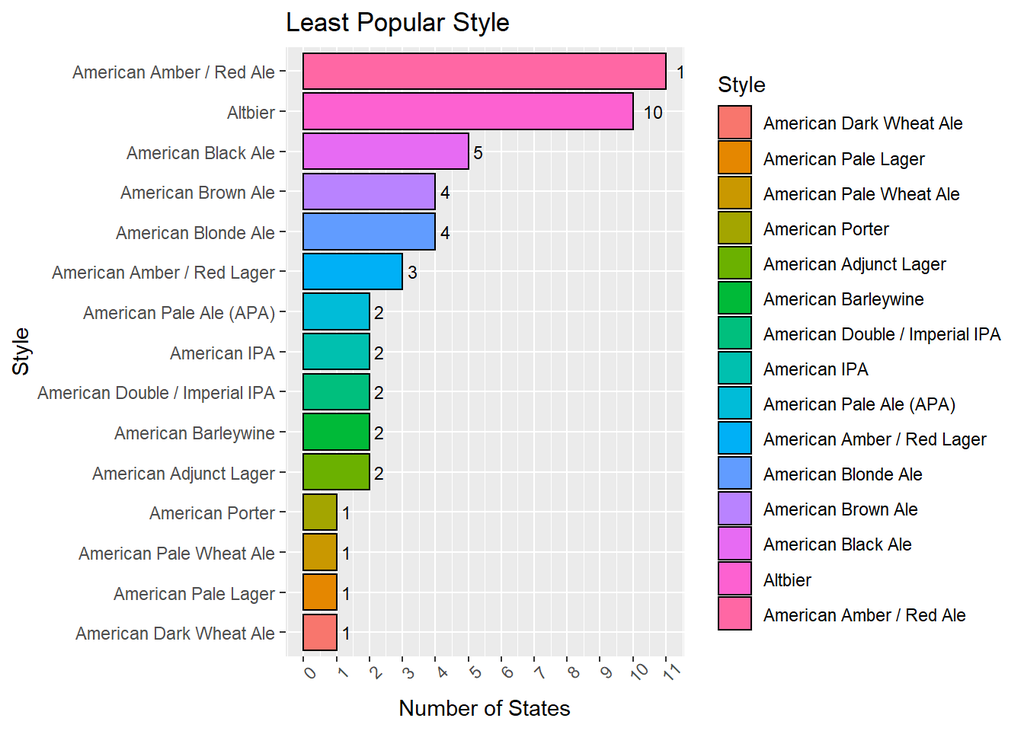

```r
beer_style_last_byState1_agr%>%
  ggplot(aes(x=Style,y=State_Total,fill=Style))+
  geom_col(position = "dodge",col="black")+ylab("Number of States")+
  theme(axis.text.x = element_text(angle = 45))+
  scale_y_continuous(breaks = scales::pretty_breaks(n = 10))+
  ggtitle("Least Popular Style")+
  geom_text(aes(label=State_Total),hjust = -0.5,size = 3)+coord_flip()
```